# Math 120 Week 9

Ali Miller

20 October, 2020

# Monday Oct 12

## Normal Dists (continued)

Recall: to find probability for a normal dist, need to FIND THE AREA under the normal curve (corresponding to our range).

Last time: practiced finding probabilities with the STANDARD NORMAL DIST: mean = 0 and std dev = 1 (ie the one in the table)

**Warm-up example** If Z has a standard normal dist, find

```
P( 0.34 < Z < 1.29) = P(Z<1.29) - P(Z < 0.34)
```

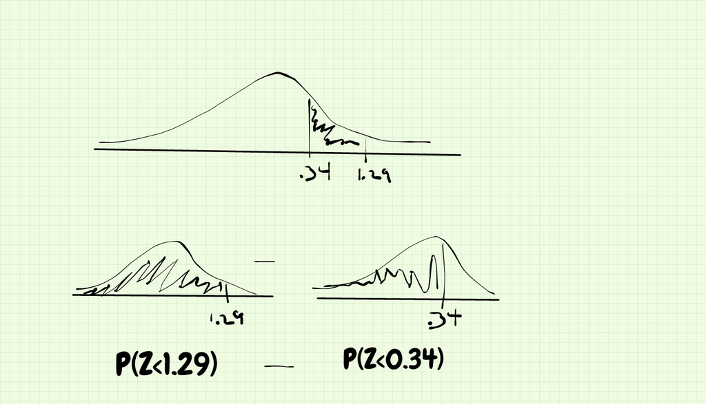

```r
.9015 - .6331
```

```
## [1] 0.2684
```

So far, all of our exmaples have been with the standard normal dist.

But what about real data? How to convert to std normal?

A: Easy, find a z-score!

```
z = (x-mean)/stdev
```

If X has a normal dist, the the above Z converts it to a std normal so we can use the table! This formula converts our data to have a mean of 0, std dev of 1.

**Example**

Heights for adult men in the US follow a normal dist (this is true) with mean 69" (also tru) and std dev 2.7" (still true!).

What’s the probability that a rando man is 70 inches tall or less?

Step 1: Get a z score! Convert our data to std normal!

```
z = (70 - 69)/2.7
```

```r
(70 - 69)/2.7
```

```
## [1] 0.3703704
```

Note: to use table, MUST round z-score to 2 decimals. Here, z = 0.37.

From table: P(Z<.37) = .6443

There’s a 64.43% chance that rando man is less than 70" tall.

**Ex** Heights for women in the US follow a normal dist with mean 64“, std dev 2.4” (that’s all true).

What’s the prob that a randomly selected woman is between 65" and 70" tall?

Idea: get z scores, look em up! Answer = big prob - small prob

x = 70:

z=

```r
(70-64)/2.4
```

```
## [1] 2.5
```

X = 65:

Z =

```r
(65 - 64)/2.4
```

```
## [1] 0.4166667
```

z = .42

Look em up!

```r
.9938 - .6628
```

```
## [1] 0.331
```

There’s a 33.1% chance that rando woman is between 65" and 70" tall.

**Ex** What’s the probabability that your math professor is as tall as she is? 75"

```r
(75-64)/2.4
```

```
## [1] 4.583333
```

Hmmmmmmmm!!! Thinking emoji!

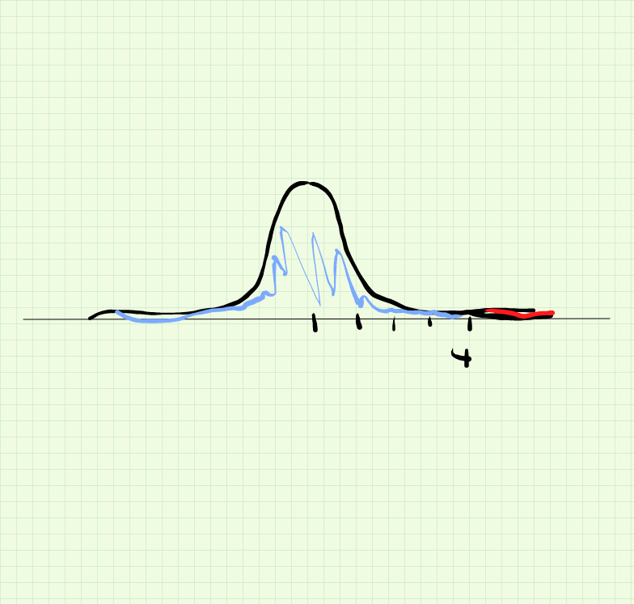

Since there’s almost no area past z=4.58,

P(Z>4.58) ~ 0 (approximately zero).

There’s almost no chance of randomly picking a woman who’s 75" or taller.

Moral of the story: statistics only tells us about populations, not individuals!

**Ex** What’s the probability that a randomly selected woman is less than 75" tall?

P(X<=75) ~ 1.

### Backwards problems

All of the problems that we’ve seen so far are “forwards problems”:

Given a z score, find a probability. Given a value, find a probability.

**Backwards problems** go the other way:

Given a probability (area), find the corresponding value.

Ex: How tall must a man be in order to be in the top 10% of men’s heights?

First, let’s do some basic ones with the z table.

**Ex** Find the z-score that’s larger than 85% of all values in the standard normal dist.

We need to find the z-score with area/probability .85 below.

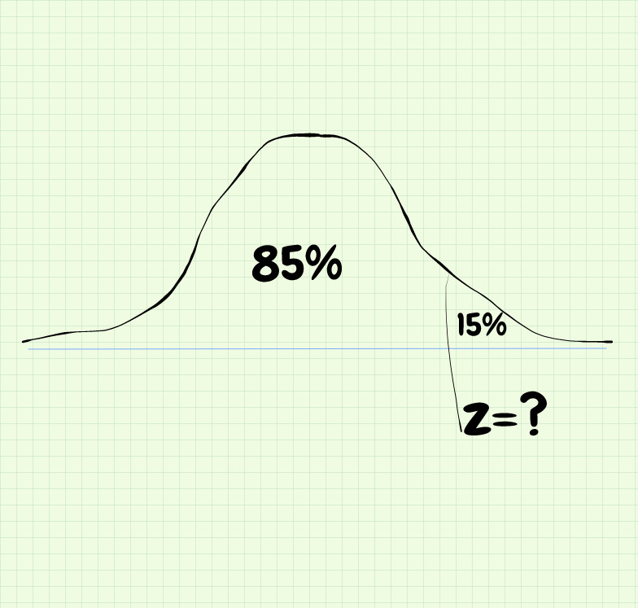

Best z-score (might not always be exact): z = 1.04.

**Ex** What’s the z-score of an individual in the top 10% of measurements.

Need to look up area = 0.9 (that’s on the left!!!)

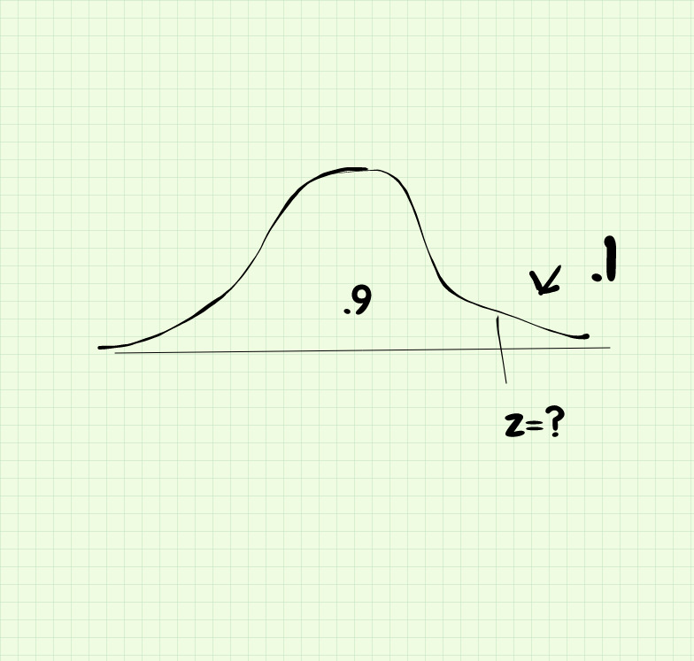

The individual would need a z-score of z=1.28.

# Friday 10-16

## Backwards Problems continued

Backwards problems are how we find “percentiles” for normal dists.

Ex: 40th percentile
$$P_{40}$$

This number is a value (not a probability!) in the dataset that’s larger than 40% of data in the distribution.

Ex: If you score in the 99th percentile (P_99), then you scored higher than 99% of test takers. (Good thing!)

Ex: A 4-year old is in the 70th percentile of heights for 4-year olds. P_70.

You already know a couple of special percentiles:

P_25 = Q_1!!! P_75 = Q_3!!! P_50 = Median

Called “order statistics”, because they show where, in order, the data is.

Backwrds problems are how we find percentiles:

### Typo Corrected!

**Ex** Reticulated giraffes have an avg height of 18.1’ and std dev of 1.6’, height follow normal dist. Calculate the 75th percentile (P_75) for giraffe heights.

Equivalent: how tall must the giraffe be in order to be taller than 75% of all giraffes.

First: need to find the z-score. Backwards problem, so look up the area in the table!

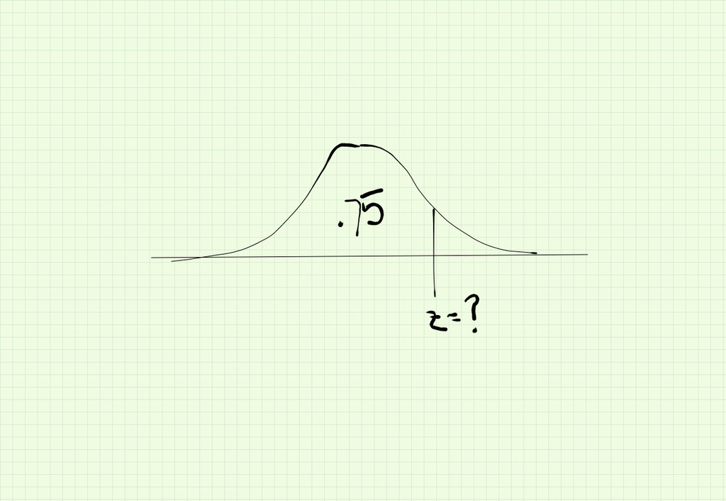

We find the z-score with area closest to 75% is z=0.67.

Not quite done: still need to know how tall the giraffe is!

```
z = (x - mean)/stdev
```

Plug in:

```
.67 = (x-18.1)/1.6
```

```r
.67*1.6+18.1
```

```
## [1] 19.172
```

Thus, the giraffe must be 19.172ft tall in order to be in the 75th percentile.

**Ex** Scores on the SAT follow a normal dist with mean 1100 and std dev 200.

How high must a student score to be in the 90th percentile, P_90?

Backwards, since we’re looking for a value (not a probability!) First, find z in the table: look up the area that’s as close as possible to .9.

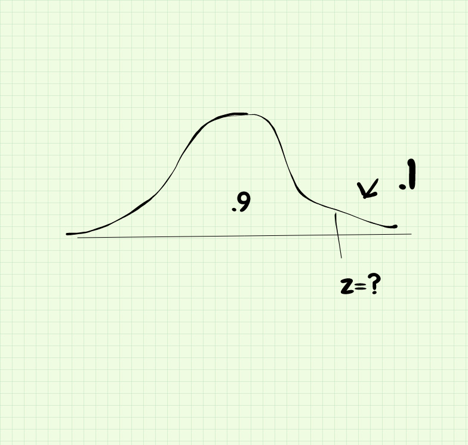

Best z-score: z = 1.28

Still need to compute the score:

```
z = (x - mean)/stdev

1.28 = (x-1100)/200
```

Find x:

```r
1.28*200+1100
```

```
## [1] 1356
```

A student would have to score 1356 in order to be in the 90th percentile.

**Special example!** Again about SAT ( mean=1100 and stdev = 200). What range of scores encompass the middle 90% of the data?

What are the cutoffs (low and high) that separate the middle 90% most common scores?

Picture! (Shown below this problem)

We see that for z_low, need to look up area of .05.

Uh-oh! There are two areas that are equally close (z-scores of -1.64 and -1.65). No problem, just split the difference:

```
z = -1.645
```

Ok, got the low z-score. What about the high? Look up area of 0.95:

```
z = +1.645
```

Note: for “middle %” problems, the z-scores always match (+/-) because the normal dist is symmetric! Gotta be the same on both sides! Don’t really need to look up both.

Still need to find the scores! No prob, plug in:

Low:

```
-1.645 = (x - 1100)/200
```

```r
-1.645*200+1100
```

```
## [1] 771
```

High:

```
+1.645 = (x - 1100)/200
```

```r
1.645*200+1100
```

```
## [1] 1429
```

Conclusion: the middle 90% of scores on the SAT are between 771 and 1429.

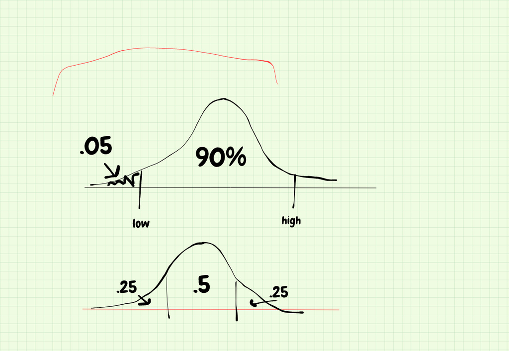

**Ex** Heights for women in the US follow a normal dist, mean = 64" and stdev = 2.4".

Find the IQR for women’s heights.

Remember, IQR is the range of the middle 50%!

Picture! (Seen above, below the previous example)

We see we need to find the area = .25. Look it up: z = -.67 is closest.

Thus, the z-scores are +/- .67

Find the heights: plug in!

```
-.67 = (x-64)/2.4
```

```r
-.67*2.4+64
```

```
## [1] 62.392
```

```
+.67 = (x-64)/2.4
```

```r
.67*2.4+64
```

```
## [1] 65.608
```

Conclusion: the middle 50% of women range between 62.392 inches and 65.608 inches.

Thus, the IQR = 65.608- 62.392

```r
65.608- 62.392
```

```
## [1] 3.216
```